# Data_wrangling

Elham Sharifin, this course is taken from Edx data wrangling course. all the key points exactly the same of the course. I solved the questions myself!

4/22/2020

## Key points: Introduction to wrnagling:

- The first step in data analysis is importing, tidying and cleaning the data. This is the process of data wrangling.
- Data analysis, for example checking correlations or creating visualizations, are done AFTER wrangling in which the data will be processed into a tidy format.
- In this course, we cover several common steps of the data wrangling process: tidying data, string processing, html parsing, working with dates and times, and text mining.

## Key points: Importing dat

- Many datasets are stored in spreadsheets. A spreadsheet is essentially a file version of a data frame with rows and columns.
- Spreadsheets have rows separated by returns and columns separated by a delimiter. The most common delimiters are comma, semicolon, white space and tab.
- Many spreadsheets are raw text files and can be read with any basic text editor. However, some formats are proprietary and cannot be read with a text editor, such as Microsoft Excel files (.xls).
- Most import functions assume that the first row of a spreadsheet file is a header with column names. To know if the file has a header, it helps to look at the file with a text editor before trying to import it.

## Key points: Paths and working directories:

- The working directory is where R looks for files and saves files by default.
- See your working directory with getwd(). Change your working directory with setwd().
- We suggest you create a directory for each project and keep your raw data inside that directory.
- Use the file.path() function to generate a full path from a relative path and a file name. Use file.path() instead of paste() because file.path() is aware of your operating system and will use the correct slashes to navigate your machine.
- The file.copy() function copies a file to a new path.

```r
#shows your working directory
getwd()
```

```
## [1] "C:/Users/elham/Desktop/Data_Science/Projects/github_share/4_Data_Wrangling"
```

```r
#changing the working directory
#setwd()
```

```r
# it shows the path of raw data inside the dslabs package and list files
path <- system.file("extdata",package = "dslabs")
path
```

```
## [1] "C:/Users/elham/Documents/R/win-library/3.6/dslabs/extdata"
```

```r
list.files(path)
```

```
## [1] "2010_bigfive_regents.xls"
## [2] "carbon_emissions.csv"
## [3] "fertility-two-countries-example.csv"
## [4] "HRlist2.txt"
## [5] "life-expectancy-and-fertility-two-countries-example.csv"
## [6] "murders.csv"
## [7] "olive.csv"
## [8] "RD-Mortality-Report_2015-18-180531.pdf"
## [9] "ssa-death-probability.csv"
```

```r
# it will copy file from dslabs package to your working directory
filename <- "murders.csv"
fullpath <- file.path(path,filename)
file.copy(fullpath,getwd())
```

```
## [1] FALSE
```

```r
#it shows if file exist in your working directory or not?
file.exists(filename)
```

```
## [1] TRUE
```

```r
# copying the data murder.csv to an existing folder named data
getwd()
```

```
## [1] "C:/Users/elham/Desktop/Data_Science/Projects/github_share/4_Data_Wrangling"
```

```r
filename <- "murders.csv"
path <- system.file("extdata",package = "dslabs")
```

```r
# there are differnt ways for copying murders into data folder
## way1:
setwd("data")
file.copy(file.path(path, filename), getwd())
```

```
## [1] FALSE
```

```r
## way2:
file.copy(file.path(path, "murders.csv"), file.path(getwd(), "data"))
```

```
## [1] FALSE
```

```r
## way3:
file.location <- file.path(system.file("extdata", package = "dslabs"), "murders.csv")
file.destination <- file.path(getwd(), "data")
file.copy(file.location, file.destination)
```

```
## [1] FALSE
```

```r
#way4: it does not work. it copies it into the parent directory
file.copy(file.path(path, "murders.csv"), getwd())
```

```
## [1] FALSE
```

## Key points:The readr and readxl Packages

- readr is the tidyverse library that includes functions for reading data stored in text file spreadsheets into R. Functions in the package include: read_csv(): comma seperated values, csv format read_tsv(): tab delimited seperated values, tsv format read_delim():general text file format,must define delimiter,txt format read.csv2(): semicolon seperated values, csv format read.table():white space seperated values, txt format These differ by the delimiter they use to split columns.
- The readxl package provides functions to read Microsoft Excel formatted files. read.excel: auto detect format. xlx, and xlsx formats read.xls: original format (xls) read.xlsx: new format, xlsx
- The excel_sheets() function gives the names of the sheets in the Excel file. These names are passed to the sheet argument for the readxl functions read_excel(), read_xls() and read_xlsx().
- The read_lines() function shows the first few lines of a file in R.

```r
library(dslabs)
library(tidyverse)    # includes readr
library(readxl)
```

```r
#it will investigate the first three lines
read_lines("murders.csv",n_max=3)
```

```
## [1] "state,abb,region,population,total" "Alabama,AL,South,4779736,135"
## [3] "Alaska,AK,West,710231,19"
```

```r
#read files in csv format
dat <- read_csv(filename) #fiename from previous part
# read file using fullpath
dat <- read_csv(fullpath)
head(dat)  #if we run in R console: we can see that file is a tibble
```

```
## # A tibble: 6 x 5
##   state      abb   region population total
##   <chr>      <chr> <chr>       <dbl> <dbl>
## 1 Alabama    AL    South     4779736   135
## 2 Alaska     AK    West       710231    19
## 3 Arizona    AZ    West      6392017   232
## 4 Arkansas   AR    South     2915918    93
## 5 California CA    West     37253956  1257
## 6 Colorado   CO    West      5029196    65
```

```r
#example:
path <- system.file("extdata",package = "dslabs")
files <- list.files(path)
files
```

```
## [1] "2010_bigfive_regents.xls"
## [2] "carbon_emissions.csv"
## [3] "fertility-two-countries-example.csv"
## [4] "HRlist2.txt"
## [5] "life-expectancy-and-fertility-two-countries-example.csv"
## [6] "murders.csv"
## [7] "olive.csv"
## [8] "RD-Mortality-Report_2015-18-180531.pdf"
## [9] "ssa-death-probability.csv"
```

```r
filename <- "murders.csv"
filename1 <- "life-expectancy-and-fertility-two-countries-example.csv"
filename2 <- "fertility-two-countries-example.csv"
dat <- read.csv(file.path(path,filename))
dat1 <- read.csv(file.path(path,filename1))
dat2 <- read.csv(file.path(path,filename2))

## excel files: suppose we have an excel file names times and the second sheet named 2016. we can read the second sheet with the following methos:
#times_2016 <- read_excel("times.xlsx", sheet = 2)
#times_2016 <- read_excel("times.xlsx", sheet = "2016")
```

## Key point: Importing Data Using R-base Functions

R-base import functions (read.csv(), read.table(), read.delim()) are different with read_… functions. R-base functions generate data frames rather than tibbles and character variables are converted to factors. This can be avoided by setting the argument stringsAsFactors=FALSE.

```r
filename <- "murders.csv"
dat2 <- read.csv(filename)
class(dat2)  #difference 1: we have data.frame not tibble
```

```
## [1] "data.frame"
```

```r
class(dat2$region) #character variables are converted to factors
```

```
## [1] "factor"
```

```r
#converting to factors can be prevented by:
dat3 <- read.csv(filename,stringsAsFactors=FALSE)
class(dat3$region)
```

```
## [1] "character"
```

## Key points: Downloading Files from the Internet

- The read_csv() function and other import functions can read a URL directly.
- If there are no variable names in the first row fo a dataset, we have to add col_names=FALSE to skip putting the first row as header
- If you want to have a local copy of the file, you can use download.file().
- tempdir() creates a directory with a name that is very unlikely not to be unique.
- tempfile() creates a character string that is likely to be a unique filename.

```r
# reading data from internet
url <- "https://raw.githubusercontent.com/rafalab/dslabs/master/inst/extdata/murders.csv"
dat <- read_csv(url)
download.file(url,"murders.csv") #downloading file on your computer
tempfile()
```

```
## [1] "C:\\Users\\elham\\AppData\\Local\\Temp\\RtmpAHUUN2\\file8903273155f"
```

```r
tmp_filename <- tempfile() #give a temporary name
download.file(url,tmp_filename)  #download it
file.remove(tmp_filename) #remove the temporary file
```

```
## [1] TRUE
```

### Exercise: importing data

```r
library(tidyverse)
library(readr)

# import the file in the following url: http://mlr.cs.umass.edu/ml/machine-learning-databases/breast-cancer-wisconsin/wdbc.data
url <- "http://mlr.cs.umass.edu/ml/machine-learning-databases/breast-cancer-wisconsin/wdbc.data"
dat <- read_csv(url,col_names=FALSE) #very important, bcd there is no header for this data
ncol(dat)
```

```
## [1] 32
```

```r
nrow(dat)
```

```
## [1] 569
```

## Key points: Tidy Data:

In tidy data, each row represents an observation and each column represents a different variable. very important!!!

In wide data, 1)each row includes several observations and 2)one of the variables is stored in the header.

```r
# Fertility data (example of tidy data)
library(tidyverse)
library(dslabs)
data(gapminder)
```

```r
# creating and investigating a tidy data frame
tidy_data <- gapminder %>%
  filter(country %in% c("South Korea","Germany")) %>%
  select(country,year,fertility)
head(tidy_data)
```

```
##       country year fertility
## 1     Germany 1960      2.41
## 2 South Korea 1960      6.16
## 3     Germany 1961      2.44
## 4 South Korea 1961      5.99
## 5     Germany 1962      2.47
## 6 South Korea 1962      5.79
```

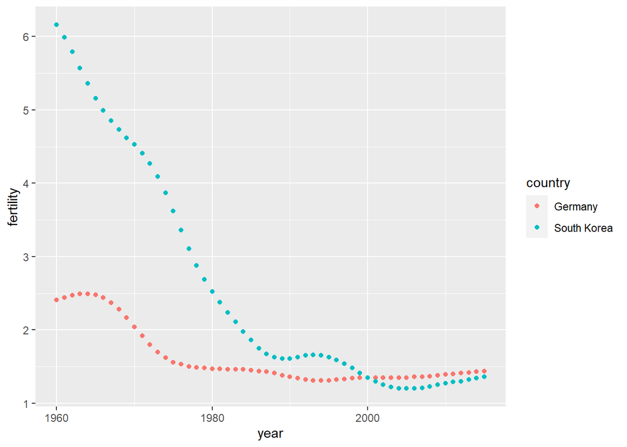

```r
#plotting fertility vs. year
tidy_data %>%
  filter(!is.na(fertility),!is.na(year)) %>%
  ggplot(aes(year,fertility, color=country)) +
  geom_point()
```

```r
# import and investigate the original Gapminder data in wide format
path <- system.file("extdata",package = "dslabs")
list.files(path)
```

```
## [1] "2010_bigfive_regents.xls"
## [2] "carbon_emissions.csv"
## [3] "fertility-two-countries-example.csv"
## [4] "HRlist2.txt"
## [5] "life-expectancy-and-fertility-two-countries-example.csv"
## [6] "murders.csv"
## [7] "olive.csv"
## [8] "RD-Mortality-Report_2015-18-180531.pdf"
## [9] "ssa-death-probability.csv"
```

```r
filename <- file.path(path,"fertility-two-countries-example.csv")
filename
```

```
## [1] "C:/Users/elham/Documents/R/win-library/3.6/dslabs/extdata/fertility-two-countries-example.csv"
```

```r
file.copy(file.path(path, "fertility-two-countries-example.csv"), file.path(getwd(), "data"))
```

```
## [1] FALSE
```

```r
wide_data <- read_csv(filename) #same info but different format
select(wide_data, country, `1960`:`1967`)
```

```
## # A tibble: 2 x 9
##   country     `1960` `1961` `1962` `1963` `1964` `1965` `1966` `1967`
##   <chr>        <dbl>  <dbl>  <dbl>  <dbl>  <dbl>  <dbl>  <dbl>  <dbl>
## 1 Germany       2.41   2.44   2.47   2.49   2.49   2.48   2.44   2.37
## 2 South Korea   6.16   5.99   5.79   5.57   5.36   5.16   4.99   4.85
```

## Key points: Reshaping data

- The tidyr package includes several functions that are useful for tidying data.
- The gather() function converts wide data into tidy data. first argument sets the name of the column that will hold the variable that is currently kept in the wide data column name.
- The spread() function converts tidy data to wide data.

```r
## the original wide data
library(tidyverse)
path <- system.file("extdata", package="dslabs")
filename <- file.path(path,  "fertility-two-countries-example.csv")
wide_data <- read_csv(filename)
## tidy data from dslab package
tidy_data <- gapminder %>%
  filter(country %in% c("South Korea","Germany")) %>%
  select(country,year,fertility)
head(tidy_data)
```

```
##       country year fertility
## 1     Germany 1960      2.41
## 2 South Korea 1960      6.16
## 3     Germany 1961      2.44
## 4 South Korea 1961      5.99
## 5     Germany 1962      2.47
## 6 South Korea 1962      5.79
```

```r
## gather wide data to make new tidy data (way 1)
new_tidy_data <- wide_data %>%
  gather(year,fertility,'1960':'2015')
# This code will gather the years from 1960 to 2015 into a single column and create a single column called “fertility” that contains the fetrility rate for each country and each year.
head(new_tidy_data)
```

```
## # A tibble: 6 x 3
##   country     year  fertility
##   <chr>       <chr>     <dbl>
## 1 Germany     1960       2.41
## 2 South Korea 1960       6.16
## 3 Germany     1961       2.44
## 4 South Korea 1961       5.99
## 5 Germany     1962       2.47
## 6 South Korea 1962       5.79
```

```r
## gather all columns except country (way 2)
new_tidy_data <- wide_data %>%
  gather(year,fertility,-country)
head(new_tidy_data)
```

```
## # A tibble: 6 x 3
##   country     year  fertility
##   <chr>       <chr>     <dbl>
## 1 Germany     1960       2.41
## 2 South Korea 1960       6.16
## 3 Germany     1961       2.44
## 4 South Korea 1961       5.99
## 5 Germany     1962       2.47
## 6 South Korea 1962       5.79
```

```r
class(tidy_data$year)
```

```
## [1] "integer"
```

```r
class(new_tidy_data$year)
```

```
## [1] "character"
```

```r
# the gather function assumes that column name are charactor and we need to convert the column to numbers!
```

```r
## convert gathered column names to numeric:
new_tidy_data <- wide_data %>%
  gather(year,fertility,-country,convert=TRUE)
head(new_tidy_data)
```

```
## # A tibble: 6 x 3
##   country      year fertility
##   <chr>       <int>     <dbl>
## 1 Germany      1960      2.41
## 2 South Korea  1960      6.16
## 3 Germany      1961      2.44
## 4 South Korea  1961      5.99
## 5 Germany      1962      2.47
## 6 South Korea  1962      5.79
```

```r
class(new_tidy_data$year)
```

```
## [1] "integer"
```

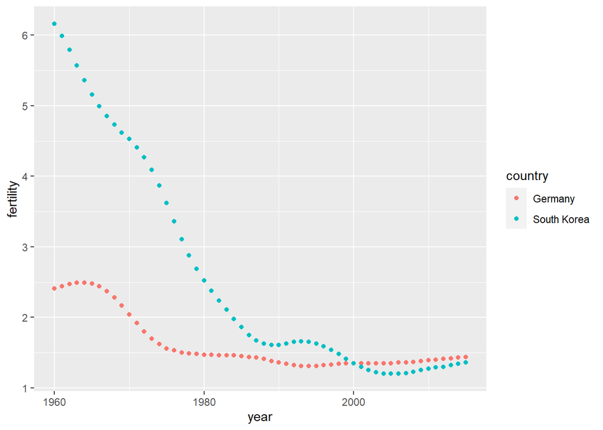

```r
## now that the data are tidy, plotting
new_tidy_data %>%
  ggplot(aes(year,fertility,color=country)) +
  geom_point()
```

```r
## spread tidy data to generate wide data
new_wide_data <- new_tidy_data %>%
  spread(year,fertility)
select(new_wide_data, country, '1960':'1967')
```

```
## # A tibble: 2 x 9
##   country     `1960` `1961` `1962` `1963` `1964` `1965` `1966` `1967`
##   <chr>        <dbl>  <dbl>  <dbl>  <dbl>  <dbl>  <dbl>  <dbl>  <dbl>
## 1 Germany       2.41   2.44   2.47   2.49   2.49   2.48   2.44   2.37
## 2 South Korea   6.16   5.99   5.79   5.57   5.36   5.16   4.99   4.85
```

## Key points: Separate and Unite

- The separate() function splits one column into two or more columns at a specified character that separates the variables. It has 3 argumnets: 1- the name of column to be seperated 2- the name to be used for the new column 3- charactor that seperates the variables
- When there is an extra separation in some of the entries, use fill=“right” to pad missing values with NAs, or use extra=“merge” to keep extra elements together.
- The unite() function combines two columns and adds a separating character.

1_Importing data:

```r
## Import data:
path <- system.file("extdata",package = "dslabs")
list.files(path)
```

```
## [1] "2010_bigfive_regents.xls"
## [2] "carbon_emissions.csv"
## [3] "fertility-two-countries-example.csv"
## [4] "HRlist2.txt"
## [5] "life-expectancy-and-fertility-two-countries-example.csv"
## [6] "murders.csv"
## [7] "olive.csv"
## [8] "RD-Mortality-Report_2015-18-180531.pdf"
## [9] "ssa-death-probability.csv"
```

```r
filename <- file.path(path,"life-expectancy-and-fertility-two-countries-example.csv")
raw_data <- read_csv(filename)
select(raw_data,1:5)
```

```
## # A tibble: 2 x 5
##   country  `1960_fertility` `1960_life_expec~ `1961_fertility` `1961_life_expec~
##   <chr>               <dbl>             <dbl>            <dbl>             <dbl>
## 1 Germany              2.41              69.3             2.44              69.8
## 2 South K~             6.16              53.0             5.99              53.8
```

2_gathering:

```r
## gather all columns but country
dat <- raw_data %>% gather(key,value,-country)
head(dat)
```

```
## # A tibble: 6 x 3
##   country     key                  value
##   <chr>       <chr>                <dbl>
## 1 Germany     1960_fertility        2.41
## 2 South Korea 1960_fertility        6.16
## 3 Germany     1960_life_expectancy 69.3
## 4 South Korea 1960_life_expectancy 53.0
## 5 Germany     1961_fertility        2.44
## 6 South Korea 1961_fertility        5.99
```

```r
dat$key[1:5]
```

```
## [1] "1960_fertility"       "1960_fertility"       "1960_life_expectancy"
## [4] "1960_life_expectancy" "1961_fertility"
```

3_seperating:

```r
## seperate on underscores
dat %>% separate(key,c("year","variable_name"),"-")
```

```
## # A tibble: 224 x 4
##    country     year                 variable_name value
##    <chr>       <chr>                <chr>         <dbl>
##  1 Germany     1960_fertility       <NA>           2.41
##  2 South Korea 1960_fertility       <NA>           6.16
##  3 Germany     1960_life_expectancy <NA>          69.3
##  4 South Korea 1960_life_expectancy <NA>          53.0
##  5 Germany     1961_fertility       <NA>           2.44
##  6 South Korea 1961_fertility       <NA>           5.99
##  7 Germany     1961_life_expectancy <NA>          69.8
##  8 South Korea 1961_life_expectancy <NA>          53.8
##  9 Germany     1962_fertility       <NA>           2.47
## 10 South Korea 1962_fertility       <NA>           5.79
## # ... with 214 more rows
```

```r
dat %>% separate(key,c("year","variable_name"))
```

```
## # A tibble: 224 x 4
##    country     year  variable_name value
##    <chr>       <chr> <chr>         <dbl>
##  1 Germany     1960  fertility      2.41
##  2 South Korea 1960  fertility      6.16
##  3 Germany     1960  life          69.3
##  4 South Korea 1960  life          53.0
##  5 Germany     1961  fertility      2.44
##  6 South Korea 1961  fertility      5.99
##  7 Germany     1961  life          69.8
##  8 South Korea 1961  life          53.8
##  9 Germany     1962  fertility      2.47
## 10 South Korea 1962  fertility      5.79
## # ... with 214 more rows
```

```r
#error: it will seperate life_expectancy to two different parts and show only the first one
```

4_1: method 1 for tyding data:

```r
## way1_1: split on first underscore but keep life_expectancy merged
dat %>%
  separate(key,c("year","variable_name"), sep="_",extra="merge")
```

```
## # A tibble: 224 x 4
##    country     year  variable_name   value
##    <chr>       <chr> <chr>           <dbl>
##  1 Germany     1960  fertility        2.41
##  2 South Korea 1960  fertility        6.16
##  3 Germany     1960  life_expectancy 69.3
##  4 South Korea 1960  life_expectancy 53.0
##  5 Germany     1961  fertility        2.44
##  6 South Korea 1961  fertility        5.99
##  7 Germany     1961  life_expectancy 69.8
##  8 South Korea 1961  life_expectancy 53.8
##  9 Germany     1962  fertility        2.47
## 10 South Korea 1962  fertility        5.79
## # ... with 214 more rows
```

```r
## way1_full code: seperate and then spread
dat %>%
  separate(key,c("year","variable_name"), sep="_",extra="merge") %>%
  spread("variable_name",value)
```

```
## # A tibble: 112 x 4
##    country year  fertility life_expectancy
##    <chr>   <chr>     <dbl>           <dbl>
##  1 Germany 1960       2.41            69.3
##  2 Germany 1961       2.44            69.8
##  3 Germany 1962       2.47            70.0
##  4 Germany 1963       2.49            70.1
##  5 Germany 1964       2.49            70.7
##  6 Germany 1965       2.48            70.6
##  7 Germany 1966       2.44            70.8
##  8 Germany 1967       2.37            71.0
##  9 Germany 1968       2.28            70.6
## 10 Germany 1969       2.17            70.5
## # ... with 102 more rows
```

4_2: method 2 for tyding data (less efficient):

```r
## way2_1: split the variable to two different ones, NA(empty)
dat %>% separate(key,c("year","first_variable_name","second_variable_name"),fill = "right")
```

```
## # A tibble: 224 x 5
##    country     year  first_variable_name second_variable_name value
##    <chr>       <chr> <chr>               <chr>                <dbl>
##  1 Germany     1960  fertility           <NA>                  2.41
##  2 South Korea 1960  fertility           <NA>                  6.16
##  3 Germany     1960  life                expectancy           69.3
##  4 South Korea 1960  life                expectancy           53.0
##  5 Germany     1961  fertility           <NA>                  2.44
##  6 South Korea 1961  fertility           <NA>                  5.99
##  7 Germany     1961  life                expectancy           69.8
##  8 South Korea 1961  life                expectancy           53.8
##  9 Germany     1962  fertility           <NA>                  2.47
## 10 South Korea 1962  fertility           <NA>                  5.79
## # ... with 214 more rows
```

```r
## way2_2: seperate and then unite
dat %>% separate(key,c("year","first_variable_name","second_variable_name"),fill = "right") %>%
  unite(variable_name,"first_variable_name","second_variable_name",sep="_")
```

```
## # A tibble: 224 x 4
##    country     year  variable_name   value
##    <chr>       <chr> <chr>           <dbl>
##  1 Germany     1960  fertility_NA     2.41
##  2 South Korea 1960  fertility_NA     6.16
##  3 Germany     1960  life_expectancy 69.3
##  4 South Korea 1960  life_expectancy 53.0
##  5 Germany     1961  fertility_NA     2.44
##  6 South Korea 1961  fertility_NA     5.99
##  7 Germany     1961  life_expectancy 69.8
##  8 South Korea 1961  life_expectancy 53.8
##  9 Germany     1962  fertility_NA     2.47
## 10 South Korea 1962  fertility_NA     5.79
## # ... with 214 more rows
```

```r
# way2_full code for tidying data (way2: using unite)
dat %>%
  separate(key,c("year","first_variable_name","second_variable_name"),fill = "right") %>%
  unite(variable_name,"first_variable_name","second_variable_name",sep="_") %>%
  spread(variable_name,value) %>%
  rename(fertility=fertility_NA)
```

```
## # A tibble: 112 x 4
##    country year  fertility life_expectancy
##    <chr>   <chr>     <dbl>           <dbl>
##  1 Germany 1960       2.41            69.3
##  2 Germany 1961       2.44            69.8
##  3 Germany 1962       2.47            70.0
##  4 Germany 1963       2.49            70.1
##  5 Germany 1964       2.49            70.7
##  6 Germany 1965       2.48            70.6
##  7 Germany 1966       2.44            70.8
##  8 Germany 1967       2.37            71.0
##  9 Germany 1968       2.28            70.6
## 10 Germany 1969       2.17            70.5
## # ... with 102 more rows
```

### Exercise1 (Reshaping Data)

Suppose we have data names time as:

age_group,2015,2016,2017 20,3:46,3:22,3:50 30,3:50,3:43,4:43 40,4:39,3:49,4:51 50,4:48,4:59,5:01

we can read the data as: > <- csv.read(“time.csv”)

we can tidy data by: >x %>% gather(year,time,‘2015’:‘2017’)

### Exercise 2:

Suppose we have the following dataset: > head(dat_wide) state year population HepatitisA Mumps Polio Rubella Alabama 1990 4040587 86 19 76 1 Alabama 1991 4066003 39 14 65 0 Alabama 1992 4097169 35 12 24 0 Alabama 1993 4133242 40 22 67 0 Alabama 1994 4173361 72 12 39 0 Alabama 1995 4216645 75 2 38 0